# R Markdown

https://github.com/Taglasov/labR

# Виды анализа данных

### 1. Прогностический анализ

Суть прогностического анализа заключается в формировании суждений будущего поведения объектов на основе анализа некоторого набора исходных данных.

Рассмотрим пример исследования, которое использует прогностический анализ данных.

##### Исследование рынка недвижимости в городе Шелехове

**https://doi.org/10.17150/2411-6262.2017.8(1).14**

В статье рассматривается анализ рынка жилья на примере моногорода Шелехов за 2015-2017 года.

Для того чтобы предсказать стоимость жилья, был использован прогностический анализ.

В ходе работы на основе регрессионного анализа были получены прогнозные значения. Также была построена оцененная линейная модель множественной регрессии:

$$y=50,51+0,75x_1+ 1,8x_2+3,39x_3+1,76x_4+5,82x_5+0,2x_6,$$
факторы:

- $x_1$ – жилая площадь квартиры, $м^2$;
- $x_2$ – площадь кухни,$м^2$; и несколько качественных факторов, имеющих только два возможных значения: 0 и 1:
- $x_3$ – серия и год построенного дома:
  1. 1 – если год новой постройки
  2. 0 – если дома старой серии;
- $x_4$ – этажность дома:
  1. 1 – если квартира расположена не на первом и не на последнем этажах;
  2. 0 – в противном случае;
- $x_5$ – наличие телефона, домофона и железной двери;
- $x_6$ – удаленность от центра: 1 – удаленность существенная, 0 – допустима и удовлетворяет покупателей.

Была получена матрица парных коэффициентов корреляции и представлена в табл. 1

**Таблица 1 – Матрица парной корреляции факторов**

|  | $x_1$ | $x_2$ | $x_3$ | $x_4$ | $x_5$ | $x_6$ |
| --- | --- | --- | --- | --- | --- | --- |
| $x_1$ | 1 |  |  |  |  |  |
| $x_2$ | 0,0617 | 1 |  |  |  |  |
| $x_3$ | 0,1806 | 0,7438 | 1 |  |  |  |
| $x_4$ | 0,1324 | 0,7671 | 0,8718 | 1 |  |  |
| $x_5$ | 0,1276 | 0,4097 | 0,7406 | 0,5535 | 1 |  |
| $x_6$ | 0,0710 | 0,0441 | 0,2115 | 0,1848 | 0,2447 | 1 |

> Результаты исследования могут быть полезны при прогнозировании тенденций развития рынка недвижимости в моногородах, для выбора оптимальной стратегии при оценке объектов недвижимости или для целей налогообложения.

### 2. Описательный анализ

Описательный анализ - это краткий и информативный анализ данных в виде графиков, таблиц и числовых выражений

Рассмотрим пример исследования, которое использует описательный анализ данных.

##### Смертность населения России в трудоспособном возрасте: гендерные и территориальные различия

**https://cyberleninka.ru/article/n/smertnost-naseleniya-rossii-v-trudosposobnom-vozraste-gendernye-i-territorialnye-razlichiya**

В данной статье выявляются показатели смертности населения России в зависимости от гендерных и территорильных различий. Простым способом узнать эти показатели является представление данных в виде таблиц и графиков.

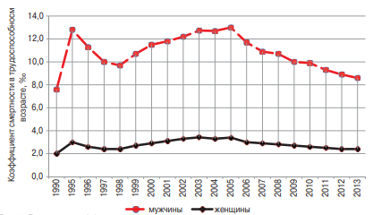

**Рис. 1.** Динамика коэффициентов смертности мужчин и женчин в трудоспособном возрасте

Из рисунка 1 можно сделать вывод:

> Показатели смертности мужчин в трудоспособном возрасте в 3–4 раза превышают показатели смертности женщин.